# Data Processing

The majority of the code deals with addressing these assumptions, using a variety of data wrangling techniques.

The first step is to download the time series data, available [here](https://github.com/nnewsh/nnewsh.github.io) It contains a spatial panel dataset comprising annual population size estimates for municipalities in the UK

```r
#Set the working directory to the downloads folder
setwd("C:/Users/niall/Downloads/")

#Read in our spatial panel of 20 years (rows) and x areas (columns)
Data <- read.csv("UK.csv")

#Inspect our data:
head(Data, 15)
```

```
##              Area            GID X2000 X2001 X2002 X2003 X2004 X2005 X2006
## 1         Central  GBR.1.1.1.1_1  9313  9351  9387  9385  9424  9481  9558
## 2          Keppel GBR.1.1.1.10_1 11744 11758 11763 11721 11745 11781 11878
## 3       Kingstone GBR.1.1.1.11_1 10102 10131 10127 10150 10188 10237 10322
## 4    Monk Bretton GBR.1.1.1.12_1 11807 11777 11821 11923 11972 12041 12050
## 5      North East GBR.1.1.1.13_1 11950 11942 11970 11968 12005 12073 12198
## 6        Old Town GBR.1.1.1.14_1 10972 10972 10992 11017 11070 11130 11208
## 7  Penistone East GBR.1.1.1.15_1 12958 12953 12956 12995 13027 13096 13192
## 8  Penistone West GBR.1.1.1.16_1 10424 10480 10511 10545 10596 10657 10743
## 9      Rockingham GBR.1.1.1.17_1 11201 11288 11323 11353 11395 11461 11553
## 10        Royston GBR.1.1.1.18_1  9964  9982 10002 10041 10083 10139 10201
## 11      St Helens GBR.1.1.1.19_1 10243 10300 10310 10291 10313 10364 10500
## 12       Cudworth  GBR.1.1.1.2_1 10946 10979 11003 11053 11100 11158 11284
## 13      Stairfoot GBR.1.1.1.20_1 11230 11215 11242 11291 11347 11415 11490
## 14           Wath GBR.1.1.1.21_1 15280 15218 15224 15216 15238 15277 15381
```

[output cut: 33 more lines]

```r
#Define the number of areas and variables - essential for subsequent data wrangling and LSTM model:
num_areas <- nrow(Data)
num_variables <- 1

#Convert spatial panel data to a long format matrix
Data.L <- Data %>%
  pivot_longer(cols = starts_with('X2'), names_to = "Year", values_to = "Population") %>%
  mutate(Year = as.numeric(sub("X", "", Year)))

data <- data.matrix(Data.L[, c(4)])

# Add row names for identification
row_names <- paste0("Area", rep(1:num_areas, each = 21), ".", rep(2000:2020, times = num_areas))
rownames(data) <- row_names

head(data, 25)
```

```
##            Population
## Area1.2000       9313
## Area1.2001       9351
## Area1.2002       9387
## Area1.2003       9385
## Area1.2004       9424
## Area1.2005       9481
## Area1.2006       9558
## Area1.2007       9644
## Area1.2008       9731
## Area1.2009       9829
## Area1.2010       9909
## Area1.2011       9977
## Area1.2012      10043
## Area1.2013      10107
## Area1.2014      10164
## Area1.2015      10204
## Area1.2016      10255
## Area1.2017      10309
## Area1.2018      10360
## Area1.2019      10409
## Area1.2020      10455
## Area2.2000      11744
## Area2.2001      11758
## Area2.2002      11763
## Area2.2003      11721
```

```r
#Clear dataframes not in use
rm(Data, Data.L, row_names)
```

Our first data manipulation task involves normalising our time series. This helps the model understand temporal dependencies in input data during training.

Normalize each feature (variable) independently to have a mean of 0. Normalize each feature (variable) independently to have a standard deviation of 1.

It is important that the mean and standard deviation correspond to the training data only. We want to avoid using any values corresponding to the test data to avoid data leakage, where information from the test set influences the model during training. This can result in overly optimistic performance estimates and potentially poor generalization to new, unseen data.

To achieve this, we first create a new dataframe containing only the training data. This dataframe will include all of our time series data except for the last 6 values. In this case, these 6 values correspond to the unseen data that is used to make the forecast (sliding window sequence size = 5, plus the target value):

Here, this new dataframe is called *train* and it is created by first creating an index with the same dimensions as our timeseries consisting of values 1 and 2. A value of 1 corresponds to the time series values that will be allocated to the training dataset, and 2 corresponds to the time series values that are reserved for testing.

```r
index <- rep(rep(c(1, 2), c(15, 6)), length.out = nrow(data))
head(index, 21)
```

```
##  [1] 1 1 1 1 1 1 1 1 1 1 1 1 1 1 1 2 2 2 2 2 2
```

```r
train <- data[index ==1, , drop = FALSE]
head(train, 15)
```

```
##            Population
## Area1.2000       9313
## Area1.2001       9351
## Area1.2002       9387
## Area1.2003       9385
## Area1.2004       9424
## Area1.2005       9481
## Area1.2006       9558
## Area1.2007       9644
## Area1.2008       9731
## Area1.2009       9829
## Area1.2010       9909
## Area1.2011       9977
## Area1.2012      10043
## Area1.2013      10107
## Area1.2014      10164
```

Next, we normalise the full time series (including train and test data) using the mean and standard deviation of the new *training set*:

```r
mean <- apply(train, 2, mean)
std <- apply(train, 2, sd)

normalized_data <- scale(data, center = mean, scale = std)
```

```r
# Remove dataframes not in use
rm(train, data, index)
```

Our next data manipulation task involves creating the sequences of our input time-series. LSTMs process the full input data by reading these sequences one by one, in what is known as a sliding window approach. Here, our window length is set to 5, meaning that each sequence consists of 5 annual population values. The first sequence therefore corresponds to the first 5 values in our time series, or the first 5 annual population values (2000 - 2004).

Each sequence is accompanied by a target value, which is the next value in the time series, or the 6th value. Recall that in backpropagation, the LSTM model estimates the next value in the sequence and uses the error (a function of the difference between the estimate and actual value) to adjust its weights and improve subsequent estimations. In our case, given a sequence length of 5, the target value corresponds to 6th value from the beginning of the sequence.

To better understand how these sequences are used by the LSTM model. Consider the formulation of our forecast task: Given a sequence of data corresponding to 5 annual population values, and sampled every one timestep (moved iteratively one year at a time), can we predict population size in the next year?

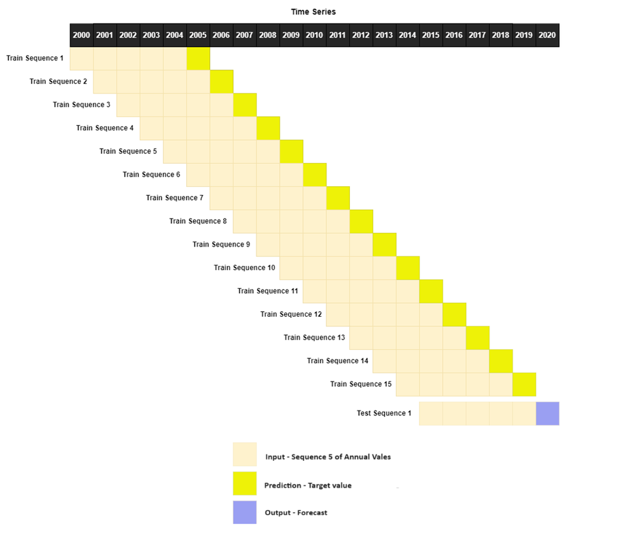

Sliding Window Process

```r
#We first establish the sliding window sequences of length 5:
window_size <- 5

#Create empty lists to store sequences and targets for each area
#Results in
sequences <- vector("list", num_areas)
targets <- vector("list", num_areas)

#Given that each sequence consists of 5 consecutive population values and is accompanied by a target, the 6th value, *each area contains 16 sequences*.
#Number of sequences = Total number of data points − Window size +1

for (i in 1:num_areas) {
#Calculate the starting row index for the current area
  start_row <- (i - 1) * 21 + 1

#Extract the population data for the current area
  area_data <- normalized_data[start_row:(start_row + 21 - 1), "Population"]

#Create empty matrices to store sequences and targets for the current area
  area_sequences <- matrix(0, nrow = length(area_data) - window_size, ncol = window_size)
  area_targets <- matrix(0, nrow = length(area_data) - window_size, ncol = 1)

#Generate sequences and targets for the current area
  for (j in 1:(length(area_data) - window_size)) {
    # Extract the sliding window sequence from the area data
    area_sequences[j, ] <- as.vector(t(area_data[j:(j + window_size - 1)]))

#Extract the target value for the next time step
    area_targets[j, ] <- area_data[j + window_size]
  }

#Store the sequences and targets in the respective lists
  sequences[[i]] <- area_sequences
  targets[[i]] <- area_targets

}

# Combine sequences and targets for all areas
all_sequences <- do.call(rbind, sequences)
all_targets <- do.call(rbind, targets)

#The can confirm this is correct by comparing all_sequences and all_targets with our normalized data.
#We expect for the 16th and final sequence to consist of data from 2015-2019 with a target corresponding to 2020:

print(normalized_data[16:21])
```

```
## [1] 0.7076072 0.7181936 0.7294027 0.7399890 0.7501602 0.7597087
```

```r
print(all_sequences[16, ])
```

```
## [1] 0.7076072 0.7181936 0.7294027 0.7399890 0.7501602
```

```r
print(all_targets[16, ])
```

```
## [1] 0.7597087
```

The next data manipulation tasks involve partitioning our sequences and targets into training and test sets. The LSTM will learn of dependencies in the training data and apply these to the test set.

```r
index <- rep(rep(c(1, 2), c(15, 1)), length.out = nrow(all_sequences))

train_data <- all_sequences[index == 1, , drop = FALSE]
train_targets <- all_targets[index == 1, , drop = FALSE]

test_data <- all_sequences[index == 2, , drop = FALSE]
test_targets <- all_targets[index == 2, , drop = FALSE]
```

Again, we can check the this has worked correctly by printing the newly created dataframes. We are expecting that our train_data to contain the first 15 sequences, corresponding to population data from 2000-2018, and our test data includes the final sequence corresponding to 2015-2019 data. The accompanying targets dataframes should contain the next value in the time-series, so that test_targets corresponds to the population at year 2020:

```r
print(train_data[15, ])
```

```
## [1] 0.6993042 0.7076072 0.7181936 0.7294027 0.7399890
```

```r
print(train_targets[15, ])
```

```
## [1] 0.7501602
```

```r
print(test_data[1, ])
```

```
## [1] 0.7076072 0.7181936 0.7294027 0.7399890 0.7501602
```

```r
print(test_targets[1, ])
```

```
## [1] 0.7597087
```

The final data manipulation tasks involves reshaping our train and test data into a format that is readable by an LSTM model. LSTM’s require input data to be formatted as a 3D array, with dimensions samples, time steps, features. In our case, these correspond to the number sequences per area (samples), sequence of input data (time steps), and number of variables (features).

This is accomplished by:

```r
train_data <- array_reshape(train_data, c(dim(train_data)[1], window_size, 1))
test_data <- array_reshape(test_data, c(dim(test_data)[1], window_size, 1))
```

[Link to next page](https://nnewsh.github.io/LSTMmodel.html)